# AFT MODELS

Author

Huayuan Chu

### Import the Data

```r
library(dplyr)
library(tidyr)
library(survminer)
library(survival)
library(broom)
library(ggsurvfit)
library(ggplot2)
# read in the data
d_s <- read.csv("../data/derived-data/PFS_Merged_Cleaned_factored.csv")
head(d_s)
```

```
  X         STUDYID  USUBJID CNSR  TRT01P PPROTFL    STARTDT        ADT AVAL
1 1 54767414MMY3008 SUBJ0001    0 TREAT A       Y 2019-04-22 2021-01-12  631
2 2 54767414MMY3008 SUBJ0002    0 TREAT A       Y 2021-10-13 2024-04-04  904
3 3 54767414MMY3008 SUBJ0003    0 TREAT B       Y 2020-10-31 2020-11-30   30
4 4 54767414MMY3008 SUBJ0004    1 TREAT A       Y 2020-12-31 2021-09-25  268
5 5 54767414MMY3008 SUBJ0005    1 TREAT A       Y 2017-10-26 2018-07-13  260
6 6 54767414MMY3008 SUBJ0006    0 TREAT B       Y 2017-02-02 2017-12-13  314
          EVNTDESC            RSSTRESC TOTAE SAECOUNT AEDECOD_MS
1            DEATH      Stable Disease     1        0     Nausea
2            DEATH Progressive Disease     2        0    Fatigue
3            DEATH    Partial Response    NA       NA       <NA>
4 ANALYSIS CUT OFF Progressive Disease     4        1  Dizziness
5     LAST CONTACT      Stable Disease     4        1    Fatigue
6            DEATH   Complete Response     2        0   Headache
           AEBODSYS AESER      AGE    SEX  RACE                 ETHNIC      LDH
1  Gastrointestinal     N 70.51563 Female White Not Hispanic or Latino 139.7219
2    Nervous System     N 79.40260 Female White Not Hispanic or Latino 115.6110
3              <NA>  <NA> 76.33235   Male White Not Hispanic or Latino 172.8269
4  Gastrointestinal     N 77.44750   Male White Not Hispanic or Latino 144.8748
5    Nervous System     N 72.06439 Female White Not Hispanic or Latino 161.9881
6 General Disorders     N 65.23182   Male White Not Hispanic or Latino 175.1388
       ALB      HGB         EXTRT EXDOSE      BMI ECOG       CRP
1 155.2226 135.7905 Dexamethasone    110 26.83260    4 12.830053
2 128.2108 131.7716   Daratumumab     30 25.42065    1  6.702462
3 159.3242 142.5922 Dexamethasone     60 32.02936    2 11.959545
4 171.4453 129.9159  Lenalidomide    150 22.04537    1  2.101916
5 131.3127 164.3331   Daratumumab    130 20.38940    1  7.230141
6 141.2525 159.1366  Lenalidomide     20 21.33275    1  6.671318
```

```r
#make columns in to categorical data column
d_s$TRT01P = as.factor(d_s$TRT01P)
d_s$EVNTDESC = as.factor(d_s$EVNTDESC)
d_s$RSSTRESC = as.factor(d_s$RSSTRESC)
d_s$AEDECOD_MS = as.factor(d_s$AEDECOD_MS)
d_s$AEBODSYS = as.factor(d_s$AEBODSYS)
d_s$AESER = as.factor(d_s$AESER)
d_s$RACE = as.factor(d_s$RACE)
d_s$SEX = as.factor(d_s$SEX)
d_s$ETHNIC = as.factor(d_s$ETHNIC)
```

### Attempt Different Combination of variables

**From the Kaplan-Meier Curve, we know that variable with smallest p-value is ‘TOTAE’(Total Adverse Event). In this section, we are trying to use different combinations of variables and use them in AFT model to see if we can get any significant variables in these combinations and which combination makes the model better. We will start with only TOTAE(Total Adverse Event) First.**

```r
#AFT Model
m1<- survreg(Surv(AVAL,1-CNSR) ~  TOTAE  ,
    data = d_s )
tidy(m1)
```

```
# A tibble: 3 × 5
  term        estimate std.error statistic  p.value
  <chr>          <dbl>     <dbl>     <dbl>    <dbl>
1 (Intercept)   6.63      0.0551    120.   0
2 TOTAE        -0.0248    0.0190     -1.31 1.91e- 1
3 Log(scale)   -0.625     0.0417    -15.0  8.93e-51
```

**From the result above, the TOTAE column is not significant(p-value greater than 0.05) when using it in a AFT model by itself. Now we want to find the combinations of variables that makes a model a good fit for the data.**

```r
candidate_vars <- c("TRT01P", "TOTAE", "SAECOUNT","AEDECOD_MS","AEBODSYS","AESER","AGE","SEX","RACE","ETHNIC","LDH","ALB","HGB","BMI","ECOG","CRP")

model_list <- list()

# Generate all combinations of the candidate variables (from 1 to n variables)
combos <- lapply(1:length(candidate_vars), function(n) combn(candidate_vars, n, simplify = FALSE))

# Flatten the list of combinations
combos <- unlist(combos, recursive = FALSE)

# Initialize the base model (just the intercept)
base_model <- survreg(Surv(AVAL, 1-CNSR) ~ 1, data = d_s, dist = "weibull")

# Fit models for each combination of variables
for (i in 1:length(combos)) {
  # Create the formula for the combination of variables
  combo_formula <- paste("Surv(AVAL, 1-CNSR) ~", paste(combos[[i]], collapse = " + "))

  # Fit the model
  new_model <- survreg(as.formula(combo_formula), data = d_s, dist = "weibull")

  # Store the model in model_list
  model_list[[i]] <- new_model

}

length(combos)
```

```
[1] 65535
```

**As you can see, there are 65535 combinations of variables. Now we want to get the top ten models that has the lowest AIC scores. AIC score is a criteria that measures how well a statistical model fits the data. Lower AIC indicates better fit.**

```r
# Initialize a data frame to store model AICs
aic_scores <- data.frame(
  model_id = integer(),
  variables = character(),
  aic = numeric()
)

# Calculate the AIC for each model and store the results
for (i in seq_along(model_list)) {
  # Extract the model
  model <- model_list[[i]]

  # Get the AIC and variable combination
  aic <- AIC(model)
  vars <- paste(attr(model$terms, "term.labels"), collapse = ", ")

  # Append to the data frame
  aic_scores <- rbind(aic_scores, data.frame(
    model_id = i,
    variables = vars,
    aic = aic
  ))
}

# Sort by AIC in ascending order and get the top 10
top_10_models <- aic_scores[order(aic_scores$aic), ][1:10, ]

# Print the top 10 models with their AICs
print(top_10_models)
```

```
    model_id          variables      aic
2          2              TOTAE 6095.054
39        39      TOTAE, ETHNIC 6095.637
43        43         TOTAE, BMI 6095.812
32        32    TOTAE, SAECOUNT 6096.262
315      315 TOTAE, ETHNIC, BMI 6096.305
17        17      TRT01P, TOTAE 6096.373
36        36         TOTAE, AGE 6096.436
3          3           SAECOUNT 6096.671
6          6              AESER 6096.734
40        40         TOTAE, LDH 6096.734
```

```r
for (i in 1:nrow(top_10_models)) {
  model_id <- top_10_models$model_id[i]
  cat("\n\nSummary of Model", i, "with variables:", top_10_models$variables[i], "\n")
  print(summary(model_list[[model_id]]))
}
```

```
Summary of Model 1 with variables: TOTAE

Call:
survreg(formula = as.formula(combo_formula), data = d_s, dist = "weibull")
              Value Std. Error      z      p
(Intercept)  6.6337     0.0551 120.30 <2e-16
TOTAE       -0.0248     0.0190  -1.31   0.19
Log(scale)  -0.6246     0.0417 -14.99 <2e-16

Scale= 0.535

Weibull distribution
Loglik(model)= -3044.5   Loglik(intercept only)= -3045.4
    Chisq= 1.68 on 1 degrees of freedom, p= 0.19
Number of Newton-Raphson Iterations: 7
n=595 (88 observations deleted due to missingness)



Summary of Model 2 with variables: TOTAE, ETHNIC

Call:
survreg(formula = as.formula(combo_formula), data = d_s, dist = "weibull")
                               Value Std. Error      z      p
(Intercept)                   6.7310     0.1012  66.54 <2e-16
TOTAE                        -0.0257     0.0190  -1.35   0.18
ETHNICNot Hispanic or Latino -0.1057     0.0912  -1.16   0.25
Log(scale)                   -0.6253     0.0417 -15.01 <2e-16

Scale= 0.535

Weibull distribution
Loglik(model)= -3043.8   Loglik(intercept only)= -3045.4
    Chisq= 3.1 on 2 degrees of freedom, p= 0.21
Number of Newton-Raphson Iterations: 7
n=595 (88 observations deleted due to missingness)



Summary of Model 3 with variables: TOTAE, BMI
```

[output cut: 140 more lines]

```
Call:
survreg(formula = as.formula(combo_formula), data = d_s, dist = "weibull")
                Value Std. Error      z      p
(Intercept)  6.623586   0.057815 114.56 <2e-16
TOTAE       -0.025674   0.019002  -1.35   0.18
LDH          0.000218   0.000387   0.56   0.57
Log(scale)  -0.625320   0.041691 -15.00 <2e-16

Scale= 0.535

Weibull distribution
Loglik(model)= -3044.4   Loglik(intercept only)= -3045.4
    Chisq= 2 on 2 degrees of freedom, p= 0.37
Number of Newton-Raphson Iterations: 7
n=595 (88 observations deleted due to missingness)
```

**From the result above, we can see that the model with only TOTAE(Total Adverse Event) as a variable has the lowest AIC score. However, the difference of the AIC scores among the top ten models are not huge. And we don’t see any significant variables among these models.**

**Now we want to use the Cox-Snell residual plots to compare how good each models fit the data.**

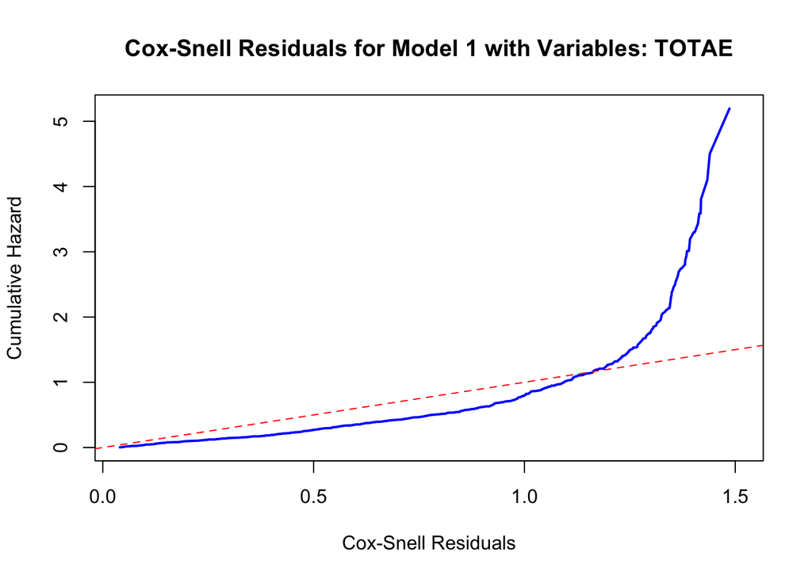

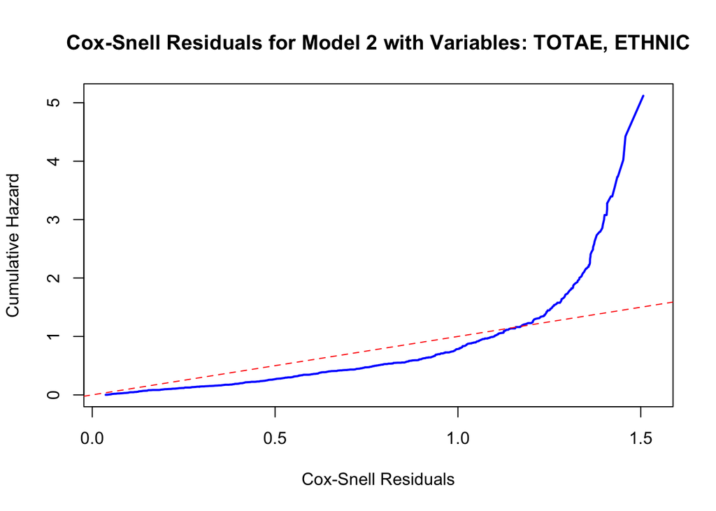

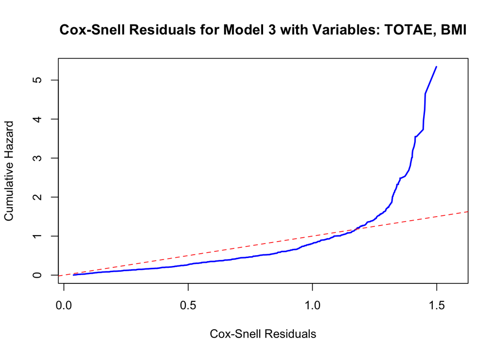

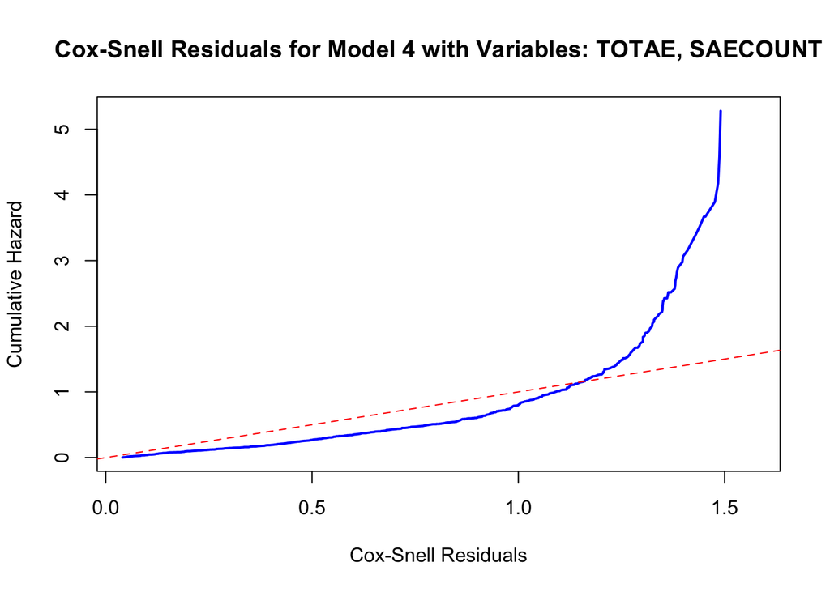

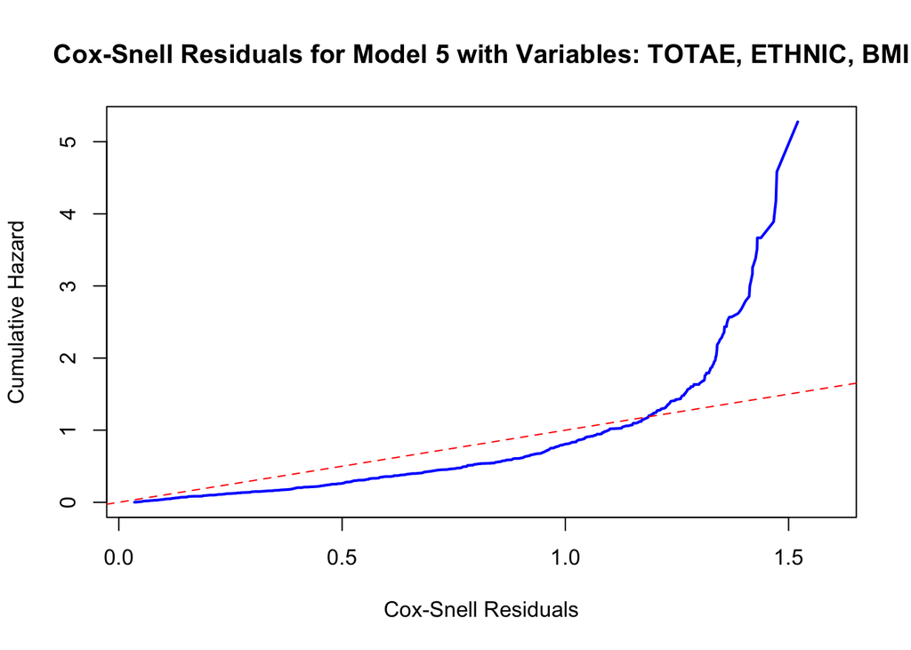

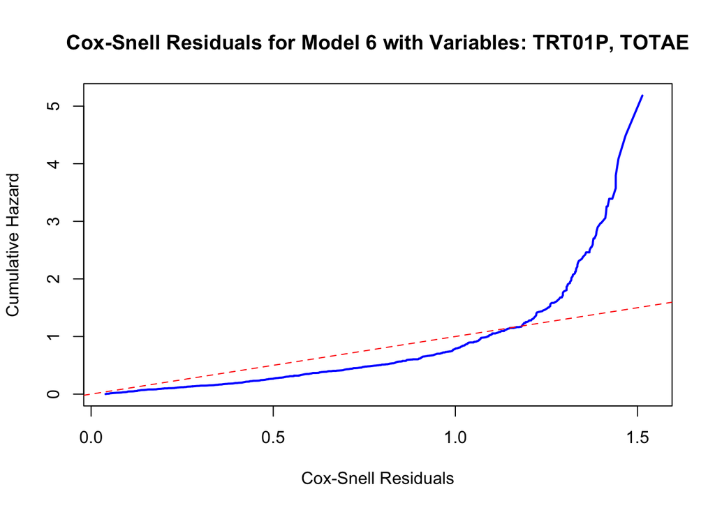

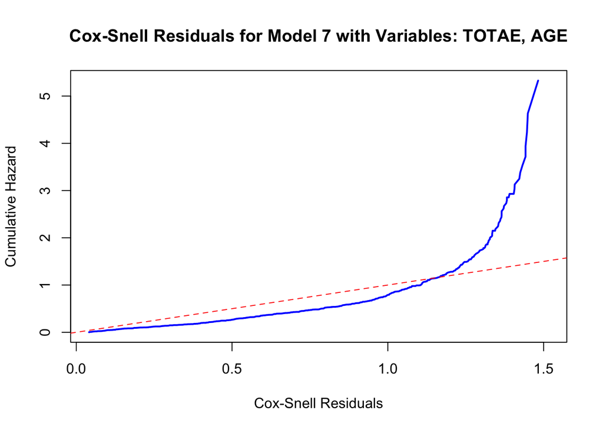

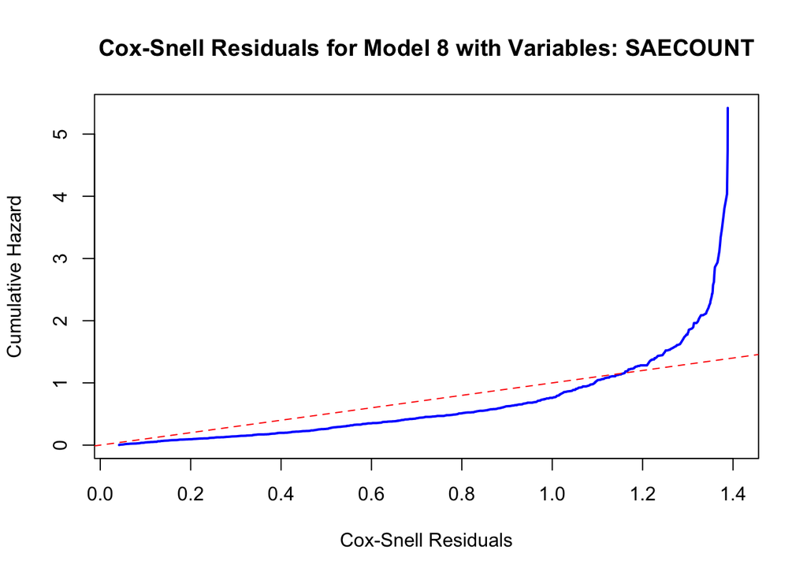

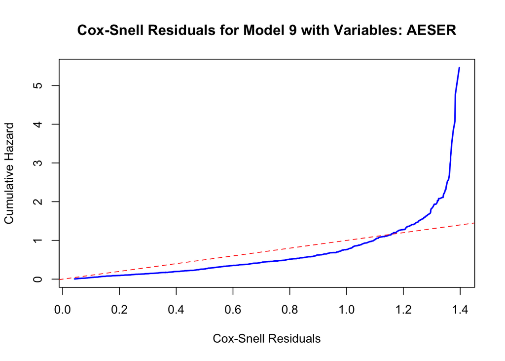

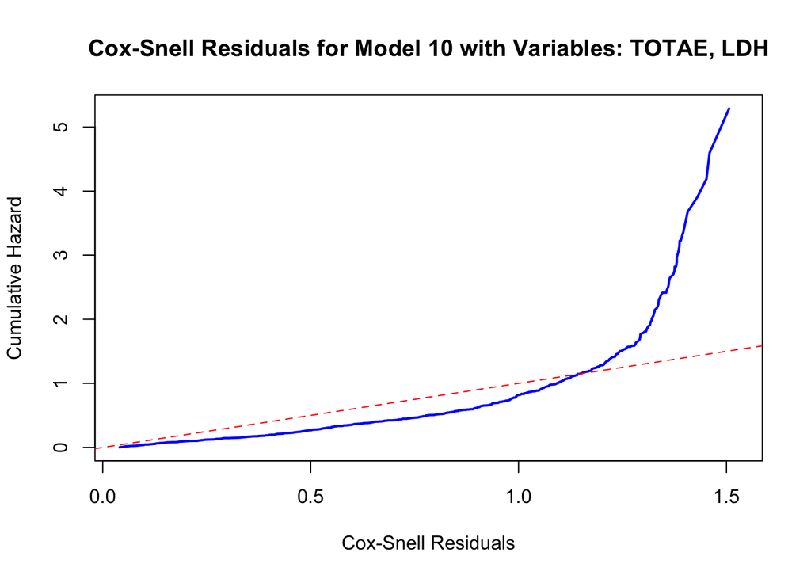

```r
# Loop through the top 10 models and generate Cox-Snell Residual plots
for (i in 1:nrow(top_10_models)) {
  model_id <- top_10_models$model_id[i]
  model <- model_list[[model_id]]

  # Calculate Cox-Snell residuals
  cox_snell_resid <- d_s$AVAL * exp(-predict(model, type = "lp"))

  # Fit a Kaplan-Meier survival curve to the Cox-Snell residuals
  km_fit <- survfit(Surv(cox_snell_resid, 1 - CNSR) ~ 1, data = d_s)

  # Calculate cumulative hazard
  cum_hazard <- -log(km_fit$surv)

  # Plot Cox-Snell residuals
  plot(
    km_fit$time, cum_hazard,
    type = "l",
    xlab = "Cox-Snell Residuals",
    ylab = "Cumulative Hazard",
    main = paste("Cox-Snell Residuals for Model", i, "with Variables:", top_10_models$variables[i]),
    col = "blue",
    lwd = 2
  )
  abline(a = 0, b = 1, col = "red", lty = 2)
}
```

**Even though the model with only TOTAE(Total Adverse Event) as a variable has the lowest AIC score, we don’t see any significant variables among these models. We now want to see the AIC scores of the model with the variables that we selected and check if there are any significant variables in it.**

```r
#AFT Model
m<- survreg(Surv(AVAL,1-CNSR) ~  TRT01P + HGB + TOTAE + SEX + ECOG ,
    data = d_s )
summary(m)
```

```
Call:
survreg(formula = Surv(AVAL, 1 - CNSR) ~ TRT01P + HGB + TOTAE +
    SEX + ECOG, data = d_s)
                  Value Std. Error      z      p
(Intercept)    6.659781   0.076908  86.59 <2e-16
TRT01PTREAT B -0.044305   0.053173  -0.83   0.40
HGB            0.000146   0.000400   0.37   0.71
TOTAE         -0.024190   0.019057  -1.27   0.20
SEXMale       -0.007066   0.053351  -0.13   0.89
ECOG          -0.004725   0.018794  -0.25   0.80
Log(scale)    -0.625178   0.041698 -14.99 <2e-16

Scale= 0.535

Weibull distribution
Loglik(model)= -3044.1   Loglik(intercept only)= -3045.4
    Chisq= 2.57 on 5 degrees of freedom, p= 0.77
Number of Newton-Raphson Iterations: 7
n=595 (88 observations deleted due to missingness)
```

```r
AIC(m)
```

```
[1] 6102.161
```

```r
m2<- survreg(Surv(AVAL,1-CNSR) ~  TOTAE ,
    data = d_s )
summary(m2)
```

```
Call:
survreg(formula = Surv(AVAL, 1 - CNSR) ~ TOTAE, data = d_s)
              Value Std. Error      z      p
(Intercept)  6.6337     0.0551 120.30 <2e-16
TOTAE       -0.0248     0.0190  -1.31   0.19
Log(scale)  -0.6246     0.0417 -14.99 <2e-16

Scale= 0.535

Weibull distribution
Loglik(model)= -3044.5   Loglik(intercept only)= -3045.4
    Chisq= 1.68 on 1 degrees of freedom, p= 0.19
Number of Newton-Raphson Iterations: 7
n=595 (88 observations deleted due to missingness)
```

```r
AIC(m2)
```

```
[1] 6095.054
```

**We compare the two models and find out that both of the two model doesn’t contain any significant variables. Now we want to compare their cox-snell residual plot and see if there is a big difference.**

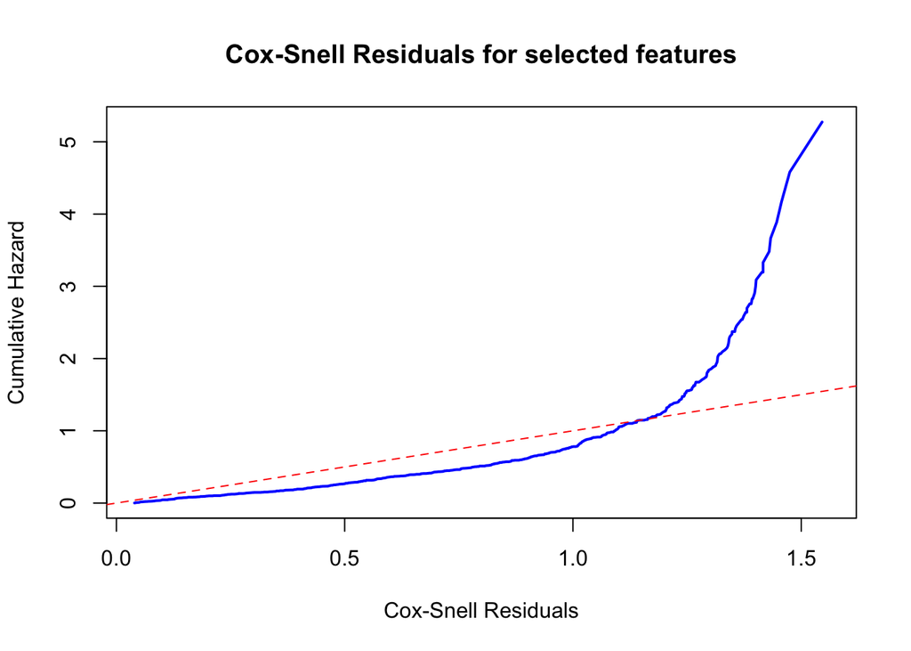

```r
cox_snell_resid <- d_s$AVAL * exp(-predict(m, type = "lp"))

km_fit <- survfit(Surv(cox_snell_resid, 1-CNSR) ~ 1,data = d_s)
cum_hazard <- -log(km_fit$surv)


plot(km_fit$time, cum_hazard,
     type = "l",
     xlab = "Cox-Snell Residuals",
     ylab = "Cumulative Hazard",
     main = "Cox-Snell Residuals for selected features",
     col = "blue",
     lwd = 2)
abline(a = 0, b = 1, col = "red", lty = 2)
```

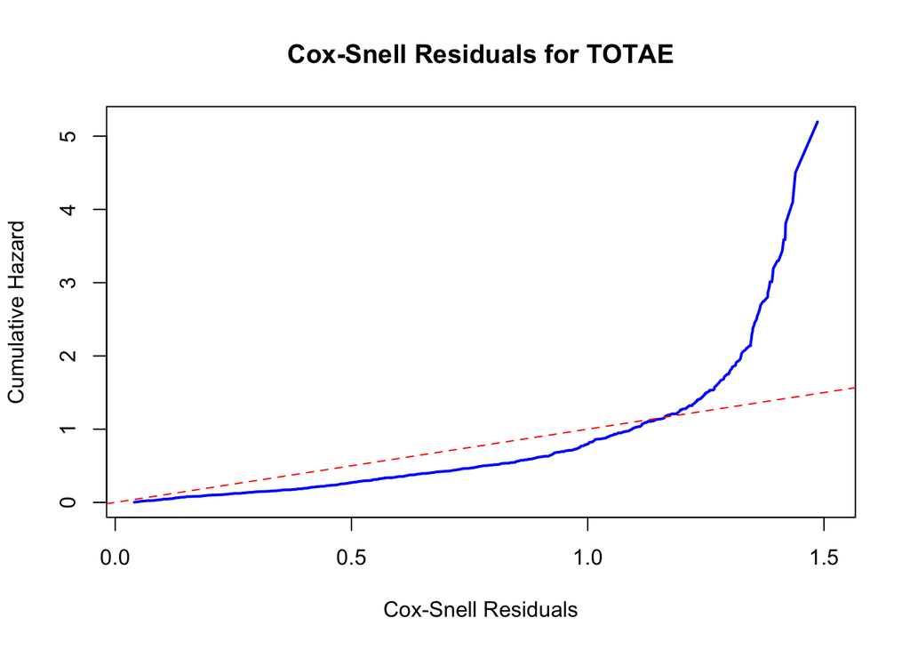

```r
cox_snell_resid <- d_s$AVAL * exp(-predict(m2, type = "lp"))

km_fit <- survfit(Surv(cox_snell_resid, 1-CNSR) ~ 1,data = d_s)
cum_hazard <- -log(km_fit$surv)


plot(km_fit$time, cum_hazard,
     type = "l",
     xlab = "Cox-Snell Residuals",
     ylab = "Cumulative Hazard",
     main = "Cox-Snell Residuals for TOTAE",
     col = "blue",
     lwd = 2)
abline(a = 0, b = 1, col = "red", lty = 2)
```

**Although 7 point is a substantial difference for AIC score, we don’t see much difference from the plots above and the p value of TOTAE(Total Adverse Event) only differentiate by 0.01. Based on the reason that we select the features, we believe we can keep our selected model and make interpretation on it.**